# Predicting Daily Citibike Trips

Nava Nizard (Hunter College)

2026-06-12

```r
repo = "https://cran.r-project.org"

install.packages("httpgd", repos = repo)
library(tidyverse)
library(modelr)
library(scales)
library(httpgd)
httpgd::hgd()
```

```
## httpgd server running at:
##   http://127.0.0.1:51330/live?token=fI3lClhE
```

```r
theme_set(theme_bw())

knitr::opts_chunk$set(echo = TRUE)

setwd("c:/Users/nava/Documents/coursework/week3/")
```

## Load data

```r
trips_per_day_total <- read_tsv("trips_per_day.tsv")
```

## Train/test split

Hold out 10% of the data as a final test set. Use the remaining 90% for training and validation.

```r
set.seed(42) # makes the random sampling reproducible

# STEP 1: FEATURE ENGINEERING THE DATA:
trips_per_day_total <- trips_per_day_total %>%
    mutate(season = case_when(month(ymd) == 12 | month(ymd) == 1 | month(ymd) == 2 ~ "winter",
                              month(ymd) == 3  | month(ymd) == 4 | month(ymd) == 5 ~ "spring",
                              month(ymd) == 6  | month(ymd) == 7 | month(ymd) == 8 ~ "summer",
                              month(ymd) == 9  | month(ymd) == 10 | month(ymd) == 11 ~ "fall")) %>%
    mutate(rain_lvl = case_when(prcp <= mean(prcp) ~ "low",
                            prcp > mean(prcp) ~ "high")) %>%
    mutate(avg_temp = (tmin + tmax) / 2) %>%
    mutate(avg_temp = case_when(avg_temp <= mean(avg_temp) ~ "cold",
                                avg_temp > mean(avg_temp) ~ "hot")) %>%
    mutate(day_of_the_week = wday(ymd, label = TRUE))
View(trips_per_day_total)

# STEP 2: SPLIT THE DATA [80 | 10 | 10] -> [train | validate | test]
num_of_days <- nrow(trips_per_day_total)
rows <- sample(num_of_days, replace = FALSE) # randomize the row indices
n_train <- floor(num_of_days * 0.8) # number of rows for the training data (80%)
n_validate <- floor(num_of_days * 0.1) # number of rows for the validate data (10%)
train <- trips_per_day_total[rows[1:n_train],] # train = 80% of data (from 0-80)
validate <- trips_per_day_total[rows[(n_train + 1):(n_train + n_validate)],] # validate = 10% of data (from 80-90)
test <- trips_per_day_total[rows[(n_train + n_validate + 1):num_of_days],] # test = 10% of data (from 90-100)
```

## Baseline model: temperature only

Start with the polynomial model from the complexity control notebook.

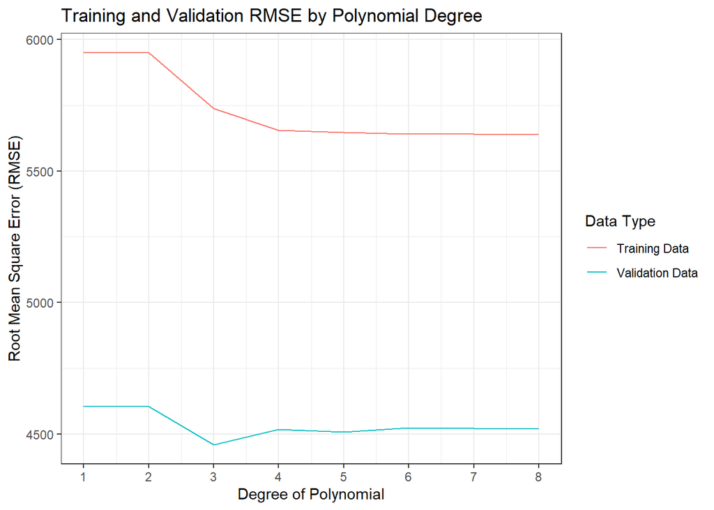

```r
# TODO: fit a linear model using poly(tmin, degree) on training data
# TODO: try different polynomial degrees and evaluate RMSE on validation data

K <- 1:8
train_err <- c() # vector with training RMSE for each degree
validate_err <- c() # vector with validatation RMSE for each degree

for (k in K) {
    tmin_model <- lm(num_trips ~ poly(tmin, k, raw = T), data = train)

    train_err[k] <- sqrt(mean((predict(tmin_model, train) - train$num_trips)^2)) # RMSE = sqrt(mean((predicted_val - actual_val)^2)
    validate_err[k] <- sqrt(mean((predict(tmin_model, validate) - validate$num_trips)^2))
}

# Plot the training and validation error as a function of the polynomial degree
plot_error_data <- data.frame(K, train_err, validate_err) %>%
    pivot_longer(names_to = 'error_type', values_to = 'RMSE', cols = -K)

plot_error_data %>%
    ggplot(aes(x = K, y = RMSE, color = error_type)) +
    geom_line() +
    scale_x_continuous(breaks = K) +
    labs(x = 'Degree of Polynomial',
         y = 'Root Mean Square Error (RMSE)',
         color = 'Data Type',
         title = 'Training and Validation RMSE by Polynomial Degree') +
    scale_color_discrete(labels = c(train_err = "Training Data",
                                    validate_err = "Validation Data"))
```

```r
# Conlusion: Choose k = 4
```

## Feature engineering

Add features that might help: day of week, month, precipitation, etc. Remember: only use information available *before* the day in question.

```r
# I did the feature engineering in an earlier step, before splitting the data.
```

## Model comparison

Try different models and compare their validation performance.

```r
seasons_model <- lm(num_trips ~ season, data = train)
seasons_r_sqr <- summary(seasons_model)$r.squared # 0.57
rmse(seasons_model, validate) < validate_err[4] # FALSE
```

```
## [1] FALSE
```

```r
rain_lvl_model <- lm(num_trips ~ rain_lvl, data = train)
rain_lvl_r_sqr <- summary(rain_lvl_model)$r.squared # 0.07
rmse(rain_lvl_model, validate) < validate_err[4] # FALSE
```

```
## [1] FALSE
```

```r
avg_temp_model <- lm(num_trips ~ avg_temp, data = train)
avg_temp_r_sqr <- summary(avg_temp_model)$r.squared # 0.66 GOOD
rmse(avg_temp_model, validate) < validate_err[4] # FALSE
```

```
## [1] FALSE
```

```r
day_of_the_week_model <- lm(num_trips ~ day_of_the_week, data = train)
day_of_the_week_r_sqr <- summary(day_of_the_week_model)$r.squared # 0.05
rmse(day_of_the_week_model, validate) < validate_err[4] # FALSE
```

```
## [1] FALSE
```

```r
seasons_and_avg_temp_model <- lm(num_trips ~ (season * avg_temp), data = train) # * slightly higher r_sqrt than +.
seasons_and_avg_temp_r_sqr <- summary(seasons_and_avg_temp_model)$r.squared # 0.71
rmse(seasons_and_avg_temp_model, validate) < validate_err[4] # FALSE
```

```
## [1] FALSE
```

```r
seasons_and_avg_temp_and_dow_model <- lm(num_trips ~ (season * avg_temp) + day_of_the_week, data = train) #
seasons_and_avg_temp_and_dow_r_sqr <- summary(seasons_and_avg_temp_and_dow_model)$r.squared # 0.76
rmse(seasons_and_avg_temp_and_dow_model, validate) < validate_err[4] # FALSE
```

```
## [1] FALSE
```

```r
all_model <- lm(num_trips ~ (season * avg_temp * rain_lvl) + day_of_the_week, data = train)
all_r_sqr <- summary(all_model)$r.squared # 0.82
rmse(all_model, validate) < validate_err[4] # TRUE
```

```
## [1] TRUE
```

```r
all2_model <- lm(num_trips ~ (season * avg_temp * rain_lvl) + day_of_the_week + snow, data = train)
all2_r_sqr <- summary(all2_model)$r.squared # 0.83
rmse(all2_model, validate) < validate_err[4] # TRUE
```

```
## [1] TRUE
```

```r
all3_model <- lm(num_trips ~ (season * avg_temp * rain_lvl * tmin) + day_of_the_week + snow, data = train)
all3_r_sqr <- summary(all3_model)$r.squared # 0.8938
rmse(all3_model, validate) < validate_err[4] # TRUE
```

```
## [1] TRUE
```

```r
all4_model <- lm(num_trips ~ (season * avg_temp * rain_lvl * tmin) + prcp + day_of_the_week + snow, data = train)
all4_r_sqr <- summary(all4_model)$r.squared # 0.8987
rmse(all4_model, validate) < validate_err[4] # TRUE
```

```
## [1] TRUE
```

```r
all5_model <- lm(num_trips ~ (season * avg_temp * rain_lvl * tmin) + prcp + day_of_the_week + snwd, data = train)
all5_r_sqr <- summary(all5_model)$r.squared # 0.90
rmse(all5_model, validate) < validate_err[4] # TRUE
```

```
## [1] TRUE
```

## Final model

Pick your best model and plot the results.

```r
final_model <- lm(num_trips ~ (season * avg_temp * rain_lvl * tmin) + prcp + day_of_the_week + snwd, data = train)
final_r_sqr <- summary(final_model)$r.squared # 0.9018
rmse(final_model, validate) < validate_err[4] # TRUE
```

```
## [1] TRUE
```

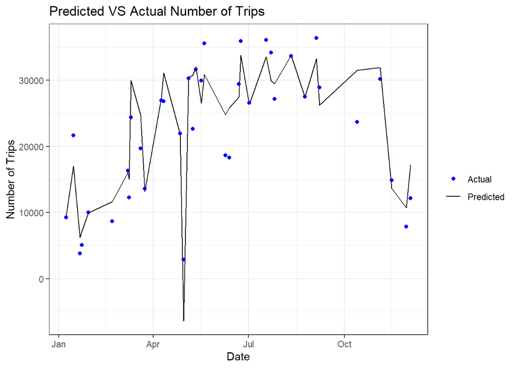

```r
predicted_trips <- predict(final_model, test)
plot_test_data <- data.frame(ymd = test$ymd, actual_trips = test$num_trips, predicted_trips)

ggplot(plot_test_data, aes(x = ymd)) +
    geom_line(aes(y = predicted_trips, color = "Predicted")) +
    geom_point(aes(y = actual_trips, color = "Actual")) +
    scale_color_manual(values = c("Predicted" = "black",
                                   "Actual" = "blue")) +
    labs(x = 'Date',
         y = 'Number of Trips',
         title = 'Predicted VS Actual Number of Trips',
         color = "",)
```

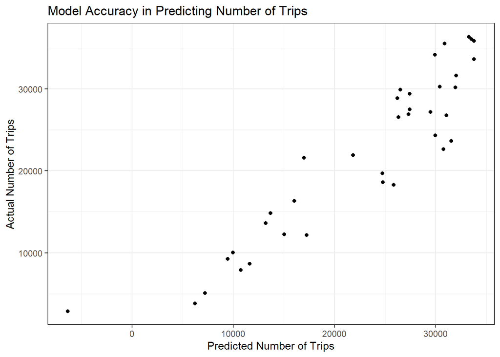

```r
ggplot(plot_test_data, aes(x = predicted_trips, y = actual_trips)) +
    geom_point() +
    labs(x = 'Predicted Number of Trips',
         y = 'Actual Number of Trips',
         title = 'Model Accuracy in Predicting Number of Trips')
```

## Save model

```r
 #.RData file using the save function.
save(final_model, file = "final_model.RData")
```

## Test set evaluation

**Do this only once, at the very end!**

```r
# TODO: load your saved model and predict on trips_test
# TODO: compute RMSE on test set
# TODO: how do you think this model will perform on future data?
load("final_model.RData")
test_rmse <- rmse(final_model, test)
test_rmse
```

```
## [1] 3887.241
```

```r
test_rmse >= rmse(final_model, validate) # TRUE, which is good!
```

```
## [1] TRUE
```

My final model had a test RMSE of 3887.2410819 trips per day. This is much lower than the baseline model’s RMSE of 4517.365304, so adding more features improved the predictions. The test RMSE was also very close to the validation RMSE of 3482.1811209, which suggests that the model performed similarly on new data and was not overfit to the training data.

I think the model will perform about the same on future data, although it could be slightly worse because differnet factors may be different from the data used to train the model.